# Exercise 6.3.3 - Model Assessment and Selection

W. Mangrobang

September 03, 2018

### Problem Statement

##### Classification Problem

**• Fit two separate classification models to a dataset.**  
**• Create a confusion matrix for each model using three different cutoff values.**  
**• Generate an ROC curve and calculate the AUC for each model.**

##### Regression Problem

**• Fit two separate regression models to a dataset (split into test and train).** **• Find the difference in AIC and BIC between the two models.** **• Calculate the RMSE and MAE for the training and test datasets.**

##### Classification Problem - Breast Cancer Dataset

We’ll leverage work we’ve already performed. Recall in Exercise 5.3.4 we created a logistic regression model on the breast cancer dataset. We’ll incorporate that work, as well as applying a different algorithm.

###### Get and prep the data

```r
# libraries
library(caret)  # ML
library(glmnet)  # regressions
library(rpart)  # decision trees
library(rpart.plot)  # tree plotting
library(tidyverse)  # tidy data and plots
library(kableExtra)  # pretty tables
library(pROC)  #ROC plots and metrics
library(scales)  #scaling and other helpers
library(stats)  #AIC/BIC
library(gridExtra)  # Gridded plots

# Set classification thresholds
thresh_1 <- 0.5
thresh_2 <- 0.75
thresh_3 <- 0.9
```

##### Build Breast Cancer Model 1: Logistic Regression

###### Prep Data

```r
# load data
bc_all <- read.csv("/users/werlindo/dropbox/pacp/data/BreastCancerWisconsinDataSet.csv")
# bc_all <-
# read.csv('d:/dropbox/pacp/data/BreastCancerWisconsinDataSet.csv')

# create binarized target
bc_all$target[bc_all$diagnosis == "M"] = 1
bc_all$target[bc_all$diagnosis == "B"] = 0
bc_all$target <- as.factor(bc_all$target)  # This is to force the logistic regression to predict 0/1

# select variables available for training
bc_all <- bc_all[, setdiff(colnames(bc_all), c("diagnosis", "id", "X"))]

# split data into training vs testing; 80%/20%
set.seed(2425)

train <- createDataPartition(bc_all$target, p = 0.8, list = FALSE)

# allocate datasets
bc_train <- bc_all[train, ]
bc_test <- bc_all[-train, ]
```

###### Build and Train

We’ll build the model and see the training results.

```r
# Set up the formula (model form) Know that target is last of 31 columns, so
# take 1:30
bc_formula <- as.formula(paste("target~", paste(names(bc_train[, -(which(names(bc_train) ==
    "target"))]), collapse = "+")))

# Create the data matrix.
X.train <- model.matrix(bc_formula, data = bc_train)
X.test <- model.matrix(bc_formula, data = bc_test)

# Run nonregularized logistic regression
bc_log <- glmnet(X.train, y = bc_train$target, family = "binomial", lambda = 0  #No regularization
)
# Predictions
# ---------------------------------------------------------------------
# Predict the probabilities
bc_log_res_probs <- predict(bc_log, newx = X.train, type = "response")

# logit2prob <- function(logit){ odds <- exp(logit) prob <- odds / (1 +
# odds) return(prob) }

# Create dataframe of predictions
bc_log_res_preds <- data.frame(thresh_1 = as.factor(1 * (bc_log_res_probs >
    thresh_1)), thresh_2 = as.factor(1 * (bc_log_res_probs > thresh_2)), thresh_3 = as.factor(1 *
    (bc_log_res_probs > thresh_3)))
```

**• Create a confusion matrix for each model using three different cutoff values.**

```r
# Confusion Matrices
# ---------------------------------------------------------------------
# Create confusion matrices for the predictions
bc_log_cm_1 <- confusionMatrix(bc_log_res_preds$thresh_1, bc_train$target)
bc_log_cm_2 <- confusionMatrix(bc_log_res_preds$thresh_2, bc_train$target)
bc_log_cm_3 <- confusionMatrix(bc_log_res_preds$thresh_3, bc_train$target)

# Create dataframe of confusion matrices
bc_res_cm_df <- data.frame(as.data.frame.matrix(bc_log_cm_1$table), as.data.frame.matrix(bc_log_cm_2$table),
    as.data.frame.matrix(bc_log_cm_3$table))

# Some column naming to support final output
bc_res_cm_df <- rownames_to_column(bc_res_cm_df, var = "Prediction")
colnames(bc_res_cm_df)[2:7] <- c("0", "1", "0", "1", "0", "1")

kable(bc_res_cm_df, caption = "Confusion Matrices | Breast Cancer Predictions | Training | Logistic Regression") %>%
    kable_styling(full_width = FALSE) %>% column_spec(2, border_left = T) %>%
    column_spec(4, border_left = T) %>% column_spec(6, border_left = T) %>%
    add_header_above(c(` ` = 1, `@ 50%` = 2, `@ 75` = 2, `@ 90%` = 2)) %>% add_header_above(c(` ` = 1,
    Reference = 6))
```

Confusion Matrices | Breast Cancer Predictions | Training | Logistic Regression

| Prediction | Reference @ 50% 0 | Reference @ 50% 1 | Reference @ 75 0 | Reference @ 75 1 | Reference @ 90% 0 | Reference @ 90% 1 |
| --- | --- | --- | --- | --- | --- | --- |
| 0 | 286 | 0 | 286 | 0 | 286 | 0 |
| 1 | 0 | 170 | 0 | 170 | 0 | 170 |

**• Generate an ROC curve and calculate the AUC for each model.**

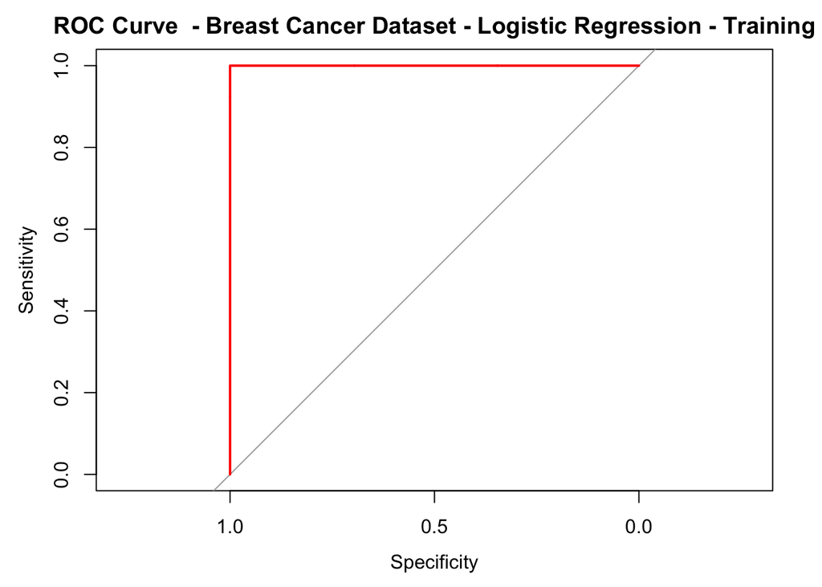

```r
# ROC Curve
# -------------------------------------------------------------------------
# Get ROC curve
plot(roc(as.numeric(bc_train$target), as.numeric(bc_log_res_probs)), col = "red",
    main = "ROC Curve  - Breast Cancer Dataset - Logistic Regression - Training")
```

```r
# AUC
# -------------------------------------------------------------------------------
# Get AUC for each model, put into matrix
a1 <- auc(bc_train$target, as.numeric(bc_log_res_preds$thresh_1))
a2 <- auc(bc_train$target, as.numeric(bc_log_res_preds$thresh_2))
a3 <- auc(bc_train$target, as.numeric(bc_log_res_preds$thresh_3))
aaa <- rbind(a1, a2, a3)

# Create df for eventual display
bc_log_aucs <- data.frame(Threshold = c(thresh_1, thresh_2, thresh_3), AUC = aaa)
rownames(bc_log_aucs) <- c()

# Make a kable
kable(bc_log_aucs, caption = "AUC - Breast Cancer Predictions - Training - Logistic Regression") %>%
    kable_styling(full_width = FALSE)
```

AUC - Breast Cancer Predictions - Training - Logistic Regression

| Threshold | AUC |
| --- | --- |
| 0.50 | 1 |
| 0.75 | 1 |
| 0.90 | 1 |

Wow. 100% accurate on training.The ROC Curve is basically a ROC square!

Let’s look at test results.

###### Run Test Data

```r
# Predictions
# ---------------------------------------------------------------------
# Predict the probabilities
bc_log_res_probs <- predict(bc_log, newx = X.test, type = "response")

# logit2prob <- function(logit){ odds <- exp(logit) prob <- odds / (1 +
# odds) return(prob) }

# Create dataframe of predictions
bc_log_res_preds <- data.frame(thresh_1 = as.factor(1 * (bc_log_res_probs >
    thresh_1)), thresh_2 = as.factor(1 * (bc_log_res_probs > thresh_2)), thresh_3 = as.factor(1 *
    (bc_log_res_probs > thresh_3)))
```

**• Create a confusion matrix for each model using three different cutoff values.**

```r
# Confusion Matrices
# ---------------------------------------------------------------------
# Create confusion matrices for the predictions
bc_log_cm_1 <- confusionMatrix(bc_log_res_preds$thresh_1, bc_test$target)
bc_log_cm_2 <- confusionMatrix(bc_log_res_preds$thresh_2, bc_test$target)
bc_log_cm_3 <- confusionMatrix(bc_log_res_preds$thresh_3, bc_test$target)

# Create dataframe of confusion matrices
bc_res_cm_df <- data.frame(as.data.frame.matrix(bc_log_cm_1$table), as.data.frame.matrix(bc_log_cm_2$table),
    as.data.frame.matrix(bc_log_cm_3$table))

# Some column naming to support final output
bc_res_cm_df <- rownames_to_column(bc_res_cm_df, var = "Prediction")
colnames(bc_res_cm_df)[2:7] <- c("0", "1", "0", "1", "0", "1")

kable(bc_res_cm_df, caption = "Confusion Matrices | Breast Cancer Predictions | Test Dataset | Logistic Regression") %>%
    kable_styling(full_width = FALSE) %>% column_spec(2, border_left = T) %>%
    column_spec(4, border_left = T) %>% column_spec(6, border_left = T) %>%
    add_header_above(c(` ` = 1, `@ 50%` = 2, `@ 75` = 2, `@ 90%` = 2)) %>% add_header_above(c(` ` = 1,
    Reference = 6))
```

Confusion Matrices | Breast Cancer Predictions | Test Dataset | Logistic Regression

| Prediction | Reference @ 50% 0 | Reference @ 50% 1 | Reference @ 75 0 | Reference @ 75 1 | Reference @ 90% 0 | Reference @ 90% 1 |
| --- | --- | --- | --- | --- | --- | --- |
| 0 | 69 | 2 | 69 | 2 | 69 | 2 |
| 1 | 2 | 40 | 2 | 40 | 2 | 40 |

**• Generate an ROC curve and calculate the AUC for each model.**

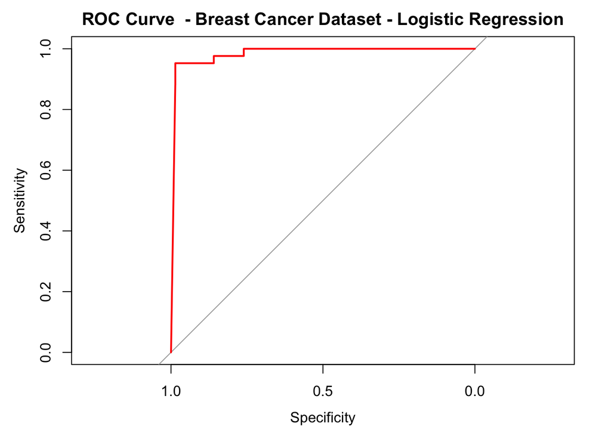

```r
# ROC Curve
# -------------------------------------------------------------------------
# Get ROC curve
plot(roc(as.numeric(bc_test$target), as.numeric(bc_log_res_probs)), col = "red",
    main = "ROC Curve  - Breast Cancer Dataset - Logistic Regression")
```

```r
# AUC
# -------------------------------------------------------------------------------
# Get AUC for each model, put into matrix
a1 <- auc(bc_test$target, as.numeric(bc_log_res_preds$thresh_1))
a2 <- auc(bc_test$target, as.numeric(bc_log_res_preds$thresh_2))
a3 <- auc(bc_test$target, as.numeric(bc_log_res_preds$thresh_3))
aaa <- rbind(a1, a2, a3)

# Create df for eventual display
bc_log_aucs <- data.frame(Threshold = c(thresh_1, thresh_2, thresh_3), AUC = aaa)
rownames(bc_log_aucs) <- c()

# Make a kable
kable(bc_log_aucs, caption = "AUC - Breast Cancer Predictions - Test Dataset - Logistic Regression") %>%
    kable_styling(full_width = FALSE)
```

AUC - Breast Cancer Predictions - Test Dataset - Logistic Regression

| Threshold | AUC |
| --- | --- |
| 0.50 | 0.962106 |
| 0.75 | 0.962106 |
| 0.90 | 0.962106 |

96% AUC at all thresholds. It’s hard for test data results to not perform as well as the training model, seeing that the training results were basically 100% accurate. But these results are very, very good as well.

##### Build Breast Cancer Model 2: Decision Tree

###### Build and Train

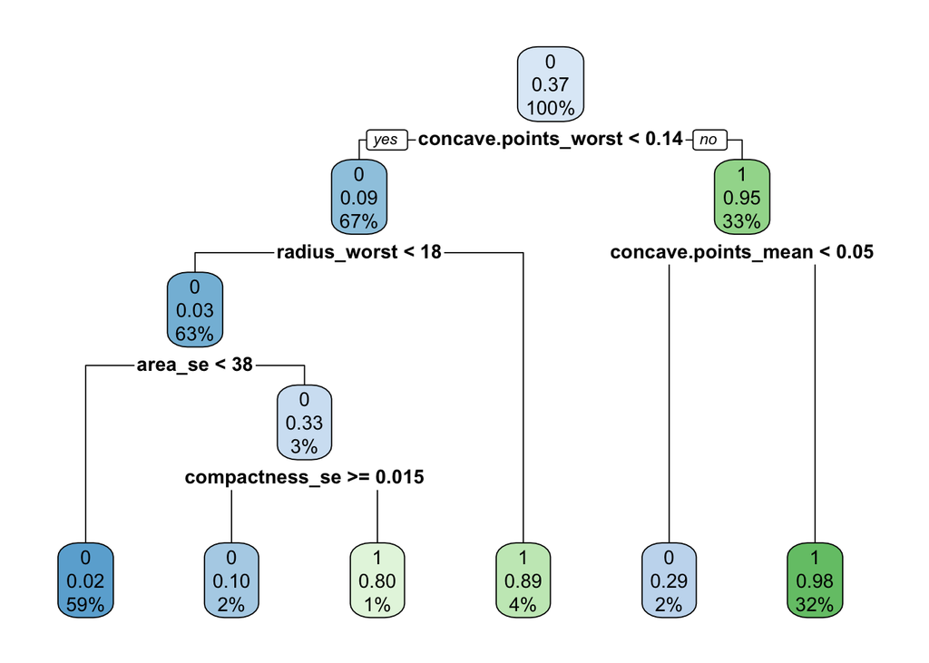

```r
# Run Modeling/Fit
# ---------------------------------------------------------------------

# Fit a decision tree, method = 'class' ensures the target is treated as a
# categorical variable
bc_dt <- rpart(bc_formula, data = bc_train, method = "class", control = rpart.control(minbucket = 5,
    cp = 1e-05, maxdepth = 5), parms = list(split = "gini"))

# Plot the tree
rpart.plot(bc_dt)
```

```r
# Predictions
# ---------------------------------------------------------------------
# Predict the probabilities
bc_dt_res_probs <- predict(bc_dt, newdata = bc_train, type = "prob")

# Create dataframe of predictions
bc_dt_res_preds <- data.frame(thresh_1 = as.factor(1 * (bc_dt_res_probs[, 2] >
    thresh_1)), thresh_2 = as.factor(1 * (bc_dt_res_probs[, 2] > thresh_2)),
    thresh_3 = as.factor(1 * (bc_dt_res_probs[, 2] > thresh_3)))
```

**• Create a confusion matrix for each model using three different cutoff values.**

```r
# Confusion Matrices
# ---------------------------------------------------------------------

# Create confusion matrices for the predictions
bc_dt_cm_1 <- confusionMatrix(bc_dt_res_preds$thresh_1, bc_train$target)
bc_dt_cm_2 <- confusionMatrix(bc_dt_res_preds$thresh_2, bc_train$target)
bc_dt_cm_3 <- confusionMatrix(bc_dt_res_preds$thresh_3, bc_train$target)

# Create dataframe of confusion matrices
bc_res_cm_df <- data.frame(as.data.frame.matrix(bc_dt_cm_1$table), as.data.frame.matrix(bc_dt_cm_2$table),
    as.data.frame.matrix(bc_dt_cm_3$table))

# Some column naming to support final output
bc_res_cm_df <- rownames_to_column(bc_res_cm_df, var = "Prediction")
colnames(bc_res_cm_df)[2:7] <- c("0", "1", "0", "1", "0", "1")

kable(bc_res_cm_df, caption = "Confusion Matrices - Breast Cancer Predictions - Training Dataset - Decision Trees") %>%
    kable_styling(full_width = FALSE) %>% column_spec(2, border_left = T) %>%
    column_spec(4, border_left = T) %>% column_spec(6, border_left = T) %>%
    add_header_above(c(` ` = 1, `@ 50%` = 2, `@ 75` = 2, `@ 90%` = 2)) %>% add_header_above(c(` ` = 1,
    Reference = 6))
```

Confusion Matrices - Breast Cancer Predictions - Training Dataset - Decision Trees

| Prediction | Reference @ 50% 0 | Reference @ 50% 1 | Reference @ 75 0 | Reference @ 75 1 | Reference @ 90% 0 | Reference @ 90% 1 |
| --- | --- | --- | --- | --- | --- | --- |
| 0 | 280 | 8 | 280 | 8 | 283 | 28 |
| 1 | 6 | 162 | 6 | 162 | 3 | 142 |

**• Generate an ROC curve and calculate the AUC for each model.**

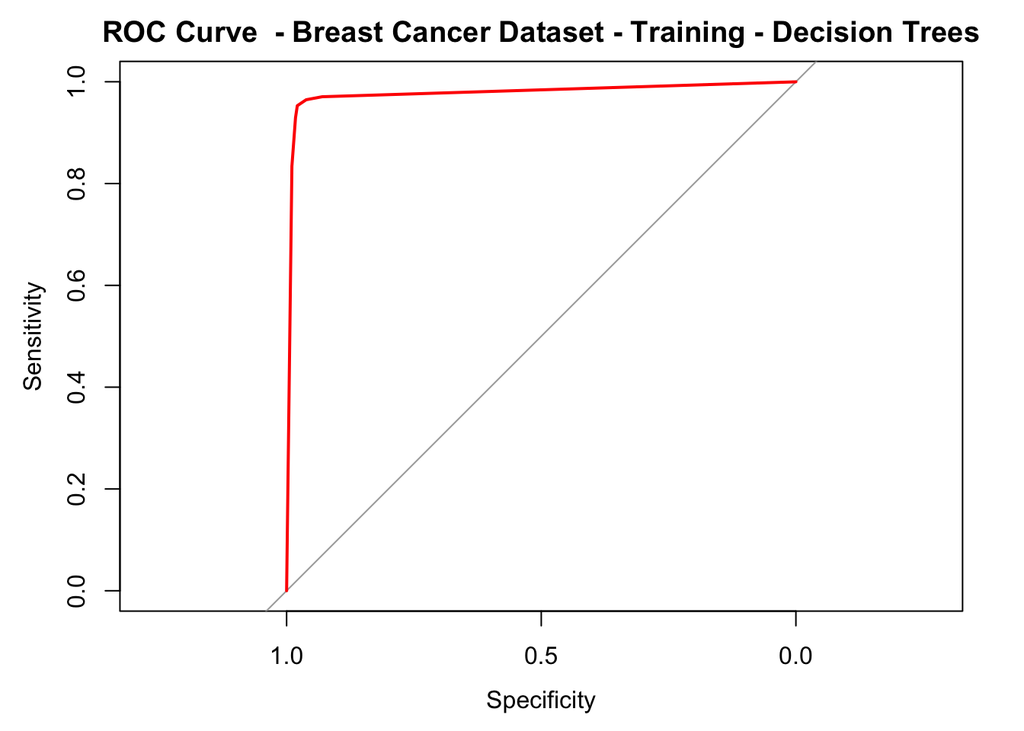

```r
# ROC Curve
# -------------------------------------------------------------------------
# Get ROC curve
plot(roc(as.numeric(bc_train$target), as.numeric(bc_dt_res_probs[, 2])), col = "red",
    main = "ROC Curve  - Breast Cancer Dataset - Training - Decision Trees")
```

```r
# AUC
# -------------------------------------------------------------------------------
# Get AUC for each model, put into matrix
a1 <- auc(bc_train$target, as.numeric(bc_dt_res_preds$thresh_1))
a2 <- auc(bc_train$target, as.numeric(bc_dt_res_preds$thresh_2))
a3 <- auc(bc_train$target, as.numeric(bc_dt_res_preds$thresh_3))
aaa <- rbind(a1, a2, a3)

# Create df for eventual display
bc_dt_aucs <- data.frame(Threshold = c(thresh_1, thresh_2, thresh_3), AUC = aaa)
rownames(bc_dt_aucs) <- c()

# Make a kable
kable(bc_dt_aucs, caption = "AUC - Breast Cancer Predictions | Training Dataset | Decision Trees") %>%
    kable_styling(full_width = FALSE)
```

AUC - Breast Cancer Predictions | Training Dataset | Decision Trees

| Threshold | AUC |
| --- | --- |
| 0.50 | 0.9659811 |
| 0.75 | 0.9659811 |
| 0.90 | 0.9124023 |

Didn’t perform as well as the logistic regression, but still pretty robust. At 90% probablility the AUC is still >.9.

###### Run Test Data

Let’s run the test data.

```r
# Run Modeling/Fit
# ---------------------------------------------------------------------

# Predictions
# ---------------------------------------------------------------------
# Predict the probabilities
bc_dt_res_probs <- predict(bc_dt, newdata = bc_test, type = "prob")

# Create dataframe of predictions
bc_dt_res_preds <- data.frame(thresh_1 = as.factor(1 * (bc_dt_res_probs[, 2] >
    thresh_1)), thresh_2 = as.factor(1 * (bc_dt_res_probs[, 2] > thresh_2)),
    thresh_3 = as.factor(1 * (bc_dt_res_probs[, 2] > thresh_3)))
```

**• Create a confusion matrix for each model using three different cutoff values.**

```r
# Confusion Matrices
# ---------------------------------------------------------------------

# Create confusion matrices for the predictions
bc_dt_cm_1 <- confusionMatrix(bc_dt_res_preds$thresh_1, bc_test$target)
bc_dt_cm_2 <- confusionMatrix(bc_dt_res_preds$thresh_2, bc_test$target)
bc_dt_cm_3 <- confusionMatrix(bc_dt_res_preds$thresh_3, bc_test$target)

# Create dataframe of confusion matrices
bc_res_cm_df <- data.frame(as.data.frame.matrix(bc_dt_cm_1$table), as.data.frame.matrix(bc_dt_cm_2$table),
    as.data.frame.matrix(bc_dt_cm_3$table))

# Some column naming to support final output
bc_res_cm_df <- rownames_to_column(bc_res_cm_df, var = "Prediction")
colnames(bc_res_cm_df)[2:7] <- c("0", "1", "0", "1", "0", "1")

kable(bc_res_cm_df, caption = "Confusion Matrices - Breast Cancer Predictions - Test Dataset - Decision Trees") %>%
    kable_styling(full_width = FALSE) %>% column_spec(2, border_left = T) %>%
    column_spec(4, border_left = T) %>% column_spec(6, border_left = T) %>%
    add_header_above(c(` ` = 1, `@ 50%` = 2, `@ 75` = 2, `@ 90%` = 2)) %>% add_header_above(c(` ` = 1,
    Reference = 6))
```

Confusion Matrices - Breast Cancer Predictions - Test Dataset - Decision Trees

| Prediction | Reference @ 50% 0 | Reference @ 50% 1 | Reference @ 75 0 | Reference @ 75 1 | Reference @ 90% 0 | Reference @ 90% 1 |
| --- | --- | --- | --- | --- | --- | --- |
| 0 | 65 | 4 | 65 | 4 | 66 | 7 |
| 1 | 6 | 38 | 6 | 38 | 5 | 35 |

**• Generate an ROC curve and calculate the AUC for each model.**

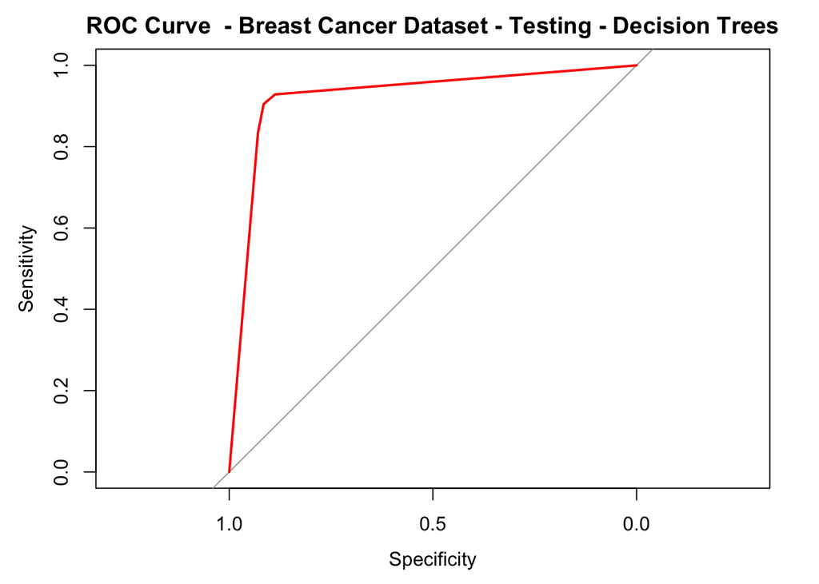

```r
# ROC Curve
# -------------------------------------------------------------------------
# Get ROC curve
plot(roc(as.numeric(bc_test$target), as.numeric(bc_dt_res_probs[, 2])), col = "red",
    main = "ROC Curve  - Breast Cancer Dataset - Testing - Decision Trees")
```

```r
# AUC
# -------------------------------------------------------------------------------
# Get AUC for each model, put into matrix
a1 <- auc(bc_test$target, as.numeric(bc_dt_res_preds$thresh_1))
a2 <- auc(bc_test$target, as.numeric(bc_dt_res_preds$thresh_2))
a3 <- auc(bc_test$target, as.numeric(bc_dt_res_preds$thresh_3))
aaa <- rbind(a1, a2, a3)

# Create df for eventual display
bc_dt_aucs <- data.frame(Threshold = c(thresh_1, thresh_2, thresh_3), AUC = aaa)
rownames(bc_dt_aucs) <- c()

# Make a kable
kable(bc_dt_aucs, caption = "AUC - Breast Cancer Predictions | Test Dataset | Decision Trees") %>%
    kable_styling(full_width = FALSE)
```

AUC - Breast Cancer Predictions | Test Dataset | Decision Trees

| Threshold | AUC |
| --- | --- |
| 0.50 | 0.9101274 |
| 0.75 | 0.9101274 |
| 0.90 | 0.8814554 |

Comparing the two models it seems that the logistic regression appears to be better performing; just slightly more accurate and robust against testing. Though in practice, implementation of decision tree logic might be easier for end users; depends on the use case.

##### Regression Problem - Diamond Price

For the regression problem we will revisit the diamond dataset.

###### Prep Data

```r
# Load diamonds dataset
library(ggplot2)  # Contains the diamonds dataset
data("diamonds")

# Take a look
head(diamonds)
```

```
## # A tibble: 6 x 10
##   carat cut       color clarity depth table price     x     y     z
##   <dbl> <ord>     <ord> <ord>   <dbl> <dbl> <int> <dbl> <dbl> <dbl>
## 1 0.23  Ideal     E     SI2      61.5    55   326  3.95  3.98  2.43
## 2 0.21  Premium   E     SI1      59.8    61   326  3.89  3.84  2.31
## 3 0.23  Good      E     VS1      56.9    65   327  4.05  4.07  2.31
## 4 0.290 Premium   I     VS2      62.4    58   334  4.2   4.23  2.63
## 5 0.31  Good      J     SI2      63.3    58   335  4.34  4.35  2.75
## 6 0.24  Very Good J     VVS2     62.8    57   336  3.94  3.96  2.48
```

```r
str(diamonds)
```

```
## Classes 'tbl_df', 'tbl' and 'data.frame':    53940 obs. of  10 variables:
##  $ carat  : num  0.23 0.21 0.23 0.29 0.31 0.24 0.24 0.26 0.22 0.23 ...
##  $ cut    : Ord.factor w/ 5 levels "Fair"<"Good"<..: 5 4 2 4 2 3 3 3 1 3 ...
##  $ color  : Ord.factor w/ 7 levels "D"<"E"<"F"<"G"<..: 2 2 2 6 7 7 6 5 2 5 ...
##  $ clarity: Ord.factor w/ 8 levels "I1"<"SI2"<"SI1"<..: 2 3 5 4 2 6 7 3 4 5 ...
##  $ depth  : num  61.5 59.8 56.9 62.4 63.3 62.8 62.3 61.9 65.1 59.4 ...
##  $ table  : num  55 61 65 58 58 57 57 55 61 61 ...
##  $ price  : int  326 326 327 334 335 336 336 337 337 338 ...
##  $ x      : num  3.95 3.89 4.05 4.2 4.34 3.94 3.95 4.07 3.87 4 ...
##  $ y      : num  3.98 3.84 4.07 4.23 4.35 3.96 3.98 4.11 3.78 4.05 ...
##  $ z      : num  2.43 2.31 2.31 2.63 2.75 2.48 2.47 2.53 2.49 2.39 ...
```

```r
# Binarize factors ------------------------------------------------------
# find the factor variables
fctrs <- names(Filter(is.factor, diamonds))
fctrs
```

```
## [1] "cut"     "color"   "clarity"
```

```r
# Binarize the factor variables, and remove them afterwards
library(fastDummies)  # fast binarizers - using dummy_cols
dia_binarized <- dummy_cols(diamonds, fctrs)
colnames(dia_binarized) <- gsub(" ", "", colnames(dia_binarized))
colnames(dia_binarized)
```

```
##  [1] "carat"        "cut"          "color"        "clarity"
##  [5] "depth"        "table"        "price"        "x"
##  [9] "y"            "z"            "cut_Ideal"    "cut_Premium"
## [13] "cut_Good"     "cut_VeryGood" "cut_Fair"     "color_E"
## [17] "color_I"      "color_J"      "color_H"      "color_F"
## [21] "color_G"      "color_D"      "clarity_SI2"  "clarity_SI1"
## [25] "clarity_VS1"  "clarity_VS2"  "clarity_VVS2" "clarity_VVS1"
## [29] "clarity_I1"   "clarity_IF"
```

```r
# Run Splits ------------------------------------------------------ split
# data into training vs testing; 80%/20%
set.seed(1001)

library(caret)  # get createDataPartition
train <- createDataPartition(dia_binarized$price, p = 0.8, list = FALSE)
# dia_train <- dia_binarized[train, ] dia_test <- dia_binarized[-train, ]
dia_train <- dia_binarized[train, !(names(dia_binarized) %in% fctrs)]
dia_test <- dia_binarized[-train, !(names(dia_binarized) %in% fctrs)]
dia_train_small <- diamonds[train, !(names(diamonds) %in% fctrs)]
dia_test_small <- diamonds[-train, !(names(diamonds) %in% fctrs)]
```

We’ll run a toy linear regression with two sets of variables. One with all the variables with the factor variables all binarized; and a ‘smaller’ one with the factor variables simply removed.

```r
# Set up the formula (model form)
dia_formula <- as.formula(paste("price~", paste(names(dia_train[, -(which(names(dia_train) ==
    "price"))]), collapse = "+")))

# Set up 'smaller' model without binarized variables
sans_bin <- colnames(diamonds[, !(names(diamonds) %in% fctrs) & !(names(diamonds) ==
    "price")])
dia_formula_small <- as.formula(paste("price~", paste(sans_bin, collapse = "+")))


# Create the data matrix.
X_train <- model.matrix(dia_formula, data = dia_train)
X_test <- model.matrix(dia_formula, data = dia_test)

X_train_small <- model.matrix(dia_formula_small, data = dia_train)
X_test_small <- model.matrix(dia_formula_small, data = dia_test)
```

```r
fit_big <- lm(dia_formula, dia_train)
fit_small <- lm(dia_formula_small, dia_train)
```

**• Find the difference in AIC and BIC between the two models.**

```r
AIC_big <- AIC(fit_big)
AIC_small <- AIC(fit_small)
AIC_big
```

```
## [1] 729556.2
```

```r
AIC_small
```

```
## [1] 753632.3
```

```r
BIC_big <- BIC(fit_big)
BIC_small <- BIC(fit_small)
BIC_big
```

```
## [1] 729773
```

```r
BIC_small
```

```
## [1] 753701.7
```

**• Calculate the RMSE and MAE for the training and test datasets.**

```r
# Get predictions
pred_big_train <- predict(fit_big)
pred_big_test <- predict(fit_big, newdata = dia_test)
pred_small_train <- predict(fit_small)
pred_small_test <- predict(fit_small, newdata = dia_test_small)

rmse_big_train <- sqrt(sum((pred_big_train - dia_train$price)^2)/dim(dia_train)[1])
rmse_big_test <- sqrt(sum((pred_big_test - dia_test$price)^2)/dim(dia_test)[1])
rmse_small_train <- sqrt(sum((pred_small_train - dia_train$price)^2)/dim(dia_train)[1])
rmse_small_test <- sqrt(sum((pred_small_test - dia_test$price)^2)/dim(dia_test)[1])
```

```r
# Get predictions
mae_big_train <- sum(abs((pred_big_train - dia_train$price))/dim(dia_train)[1])
mae_big_test <- sum(abs((pred_big_test - dia_test$price))/dim(dia_test)[1])
mae_small_train <- sum(abs((pred_small_train - dia_train$price))/dim(dia_train)[1])
mae_small_test <- sum(abs((pred_small_test - dia_test$price))/dim(dia_test)[1])
```

```r
# Create vectors for results table contents
model_name <- c("Model 1", "Model 2")
model_desc <- c(paste(dia_formula[2], dia_formula[1], dia_formula[3]), paste(dia_formula_small[2],
    dia_formula_small[1], dia_formula_small[3]))
v_AIC <- c(AIC_big, AIC_small)
v_BIC <- c(BIC_big, BIC_small)
v_rmse_train <- c(rmse_big_train, rmse_small_train)
v_rmse_test <- c(rmse_big_test, rmse_small_test)
v_mae_train <- c(mae_big_train, mae_small_train)
v_mae_test <- c(mae_big_test, mae_small_test)

# Make df of results
dia_results <- data.frame(model_name, model_desc, v_AIC, v_BIC, v_rmse_train,
    v_rmse_test, v_mae_train, v_mae_test)
header <- c("Model", "Model Formula", "AIC", "BIC", "RMSE-Train", "RMSE-Test",
    "MAE-Train", "MAE-Test")
colnames(dia_results) <- header
# head(dia_results)

# Viz table
kable(dia_results, caption = "Regression Validation Metrics | Diamond Price Predictions | Train and Test | Multivariate Linear Regressions") %>%
    kable_styling(full_width = FALSE) %>% column_spec(2:5, border_left = T) %>%
    column_spec(7, border_left = T)
```

Regression Validation Metrics | Diamond Price Predictions | Train and Test | Multivariate Linear Regressions

| Model | Model Formula | AIC | BIC | RMSE-Train | RMSE-Test | MAE-Train | MAE-Test |
| --- | --- | --- | --- | --- | --- | --- | --- |
| Model 1 | price ~ carat + depth + table + x + y + z + cut_Ideal + cut_Premium + cut_Good + cut_VeryGood + cut_Fair + color_E + color_I + color_J + color_H + color_F + color_G + color_D + clarity_SI2 + clarity_S… | 729556.2 | 729773.0 | 1134.347 | 1114.894 | 740.8970 | 740.9765 |
| Model 2 | price ~ carat + depth + table + x + y + z | 753632.3 | 753701.7 | 1499.931 | 1496.829 | 891.7853 | 896.8408 |

Model 2 is higher across the board on all validation metrics, which is the hope of the more complex Model 1. So model 1 should be a better fitting model overall.

Comparing RMSE’s and MAE’s between train and test, there’s not a noticeable degradation from train to test, which seems to indicate that the models are not overfitted.

Let’s look at the plots of the predictions (test set)!

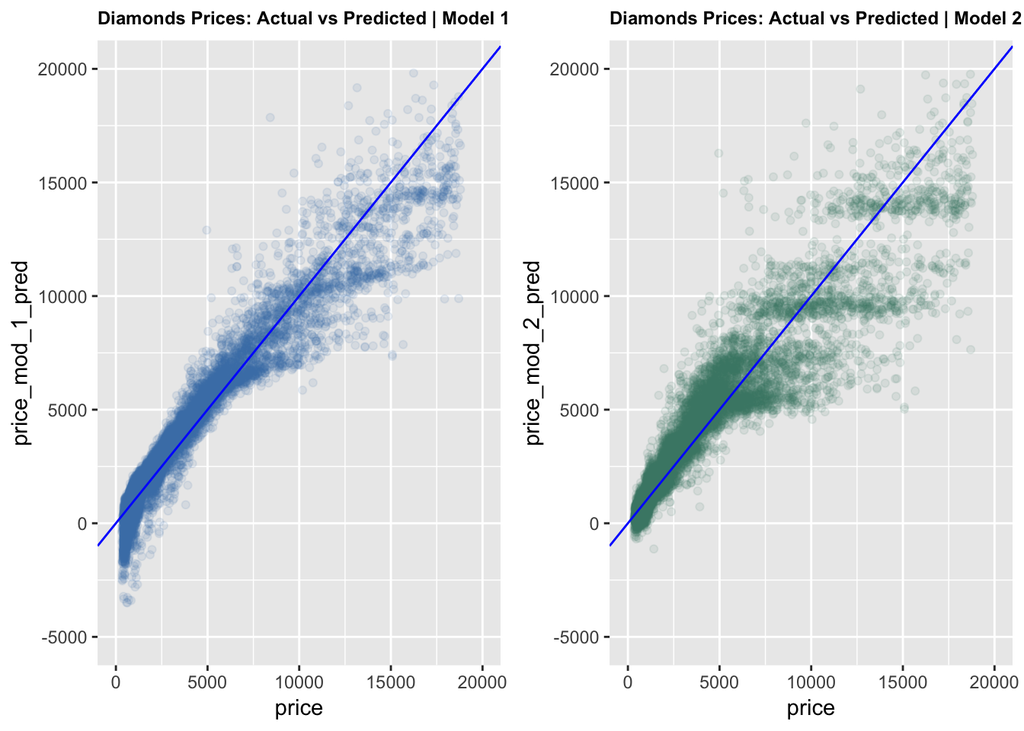

```r
dia_preds_df <- data.frame(price = dia_test$price, price_mod_1_pred = pred_big_test,
    price_mod_2_pred = pred_small_test)

plot_mod_1 <- ggplot(dia_preds_df, aes(x = price, y = price_mod_1_pred)) + geom_point(alpha = 0.1,
    color = "steelblue") + xlim(0, 20000) + ylim(-5000, 20000) + geom_abline(intercept = 0,
    slope = 1, color = "blue") + ggtitle("Diamonds Prices: Actual vs Predicted | Model 1") +
    theme(plot.title = element_text(size = 9, face = "bold"))

plot_mod_2 <- ggplot(dia_preds_df, aes(x = price, y = price_mod_2_pred)) + geom_point(alpha = 0.1,
    color = "aquamarine4") + xlim(0, 20000) + ylim(-5000, 20000) + geom_abline(intercept = 0,
    slope = 1, color = "blue") + ggtitle("Diamonds Prices: Actual vs Predicted | Model 2") +
    theme(plot.title = element_text(size = 9, face = "bold"))

# colors()
grid.arrange(plot_mod_1, plot_mod_2, ncol = 2)
```

Makes sense. Model 1 per metrics appears to be better fit; and we can see that visually by how the points of model 1 appear to be ‘tighter’ around the 45 degree line. Model 2 is interesting in that it seems to produce less negative predicted prices.

**Footnotes:**  
*2018.09.03: Fixed mislabeled figure headers in section 1*